🏠 Inicio del curso | 📊 Modelos ARCH y GARCH

# Estimación ARCH y GARCH — AMZN

Andrés Londoño

Continuación directa de Volatilidad histórica y EWMA sobre el mismo activo (AMZN): se ajusta primero el modelo de la **media** (ARIMA), se valida que sus residuales tengan varianza cambiante (heterocedasticidad), y luego se modela esa varianza con **ARCH(1)** y **GARCH(1,1)**, comparando cuál deja menos estructura sin explicar.

```r
if (!require("pacman")) install.packages("pacman")
pacman::p_load(tidyverse, xts, tseries, magrittr, ggpubr, zoo, forecast,
               quantmod, MTS, zoo, FinTS, fGarch, lmtest, scales, aTSA)

## 1. Definicion automatica de la ruta de trabajo ----
if (!require("rstudioapi")) install.packages("rstudioapi")
tryCatch(setwd(dirname(rstudioapi::getActiveDocumentContext()$path)), error = function(e) NULL)
```

```r
options(scipen = 999)
source("Pruebas residuales ARIMA.R")
```

Igual que en la clase de series de tiempo, las pruebas de raíz unitaria y de heterocedasticidad (ARCH-LM) que se usan más abajo no vienen de una función de un solo paquete, sino de dos funciones tabuladas (`tabla.Box.Pierce` y `tabla.ARCH.LM`) que corren la prueba para varios rezagos de una sola vez — definidas en `Pruebas residuales ARIMA.R`, en la misma carpeta.

## 1. Datos y comprobación de estacionariedad

```r
# 2. Carga de precios y calculo de retornos diarios ----

acciones <- c("AMZN")

precio <- quantmod::getSymbols(acciones, src = "yahoo",
                               from = "2023-12-31",
                               to = "2026-08-31",
                               periodicity = "daily",
                               auto.assign = TRUE,
                               warnings = FALSE) %>%
  purrr::map(~quantmod::Ad(get(.))) %>%
  purrr::reduce(merge.xts) %>%
  `colnames<-`(acciones)

retornos <- TTR::ROC(precio,
                     type = "continuous",
                     na.pad = TRUE) %>%
  na.omit()

## 2.1 Probando la existencia de raices unitarias ----

# Se pasa un vector numerico (as.numeric) y no el objeto xts: aTSA::adf.test
# sobre un xts produce un artefacto (estadisticos positivos y crecientes con
# el rezago, p=0.99) que no corresponde a la serie real.
precio.num <- as.numeric(precio)
retornos.num <- as.numeric(retornos)

precio.num %>% aTSA::adf.test()
```

```
## Augmented Dickey-Fuller Test
## alternative: stationary
##
## Type 1: no drift no trend
##      lag   ADF p.value
## [1,]   0 0.749   0.859
## [2,]   1 0.700   0.845
## [3,]   2 0.771   0.866
## [4,]   3 0.762   0.863
## [5,]   4 0.782   0.869
## [6,]   5 0.683   0.841
## [7,]   6 0.706   0.847
## Type 2: with drift no trend
##      lag   ADF p.value
## [1,]   0 -2.04   0.312
## [2,]   1 -2.17   0.262
## [3,]   2 -2.18   0.256
## [4,]   3 -2.18   0.256
## [5,]   4 -2.05   0.306
## [6,]   5 -2.15   0.266
## [7,]   6 -2.06   0.303
## Type 3: with drift and trend
##      lag   ADF p.value
## [1,]   0 -3.73  0.0222
## [2,]   1 -3.96  0.0103
## [3,]   2 -3.90  0.0133
## [4,]   3 -3.94  0.0114
## [5,]   4 -3.80  0.0184
## [6,]   5 -4.09  0.0100
## [7,]   6 -3.99  0.0100
## ----
## Note: in fact, p.value = 0.01 means p.value <= 0.01
```

```r
precio.num %>% aTSA::pp.test()
```

```
## Phillips-Perron Unit Root Test
## alternative: stationary
##
## Type 1: no drift no trend
##  lag Z_rho p.value
##    6 0.392    0.78
## -----
##  Type 2: with drift no trend
##  lag Z_rho p.value
##    6 -8.34   0.268
## -----
##  Type 3: with drift and trend
##  lag Z_rho p.value
##    6 -30.4    0.01
## ---------------
## Note: p-value = 0.01 means p.value <= 0.01
```

```r
precio.num %>% aTSA::kpss.test()
```

```
## KPSS Unit Root Test
## alternative: nonstationary
##
## Type 1: no drift no trend
##  lag   stat p.value
##    5 0.0558     0.1
## -----
##  Type 2: with drift no trend
##  lag  stat p.value
##    5 0.275     0.1
## -----
##  Type 1: with drift and trend
##  lag   stat p.value
##    5 0.0352     0.1
## -----------
## Note: p.value = 0.01 means p.value <= 0.01
##     : p.value = 0.10 means p.value >= 0.10
```

```r
retornos.num %>% aTSA::adf.test()
```

```
## Augmented Dickey-Fuller Test
## alternative: stationary
##
## Type 1: no drift no trend
##      lag   ADF p.value
## [1,]   0 -24.8    0.01
## [2,]   1 -18.6    0.01
## [3,]   2 -15.1    0.01
## [4,]   3 -13.4    0.01
## [5,]   4 -11.2    0.01
## [6,]   5 -10.5    0.01
## [7,]   6 -10.4    0.01
## Type 2: with drift no trend
##      lag   ADF p.value
## [1,]   0 -24.9    0.01
## [2,]   1 -18.6    0.01
## [3,]   2 -15.1    0.01
## [4,]   3 -13.5    0.01
## [5,]   4 -11.2    0.01
## [6,]   5 -10.5    0.01
## [7,]   6 -10.5    0.01
## Type 3: with drift and trend
##      lag   ADF p.value
## [1,]   0 -24.8    0.01
## [2,]   1 -18.6    0.01
## [3,]   2 -15.1    0.01
## [4,]   3 -13.5    0.01
## [5,]   4 -11.2    0.01
## [6,]   5 -10.5    0.01
## [7,]   6 -10.5    0.01
## ----
## Note: in fact, p.value = 0.01 means p.value <= 0.01
```

```r
retornos.num %>% aTSA::pp.test()
```

```
## Phillips-Perron Unit Root Test
## alternative: stationary
##
## Type 1: no drift no trend
##  lag Z_rho p.value
##    6  -624    0.01
## -----
##  Type 2: with drift no trend
##  lag Z_rho p.value
##    6  -622    0.01
## -----
##  Type 3: with drift and trend
##  lag Z_rho p.value
##    6  -622    0.01
## ---------------
## Note: p-value = 0.01 means p.value <= 0.01
```

```r
retornos.num %>% aTSA::kpss.test()
```

```
## KPSS Unit Root Test
## alternative: nonstationary
##
## Type 1: no drift no trend
##  lag  stat p.value
##    5 0.485     0.1
## -----
##  Type 2: with drift no trend
##  lag   stat p.value
##    5 0.0377     0.1
## -----
##  Type 1: with drift and trend
##  lag   stat p.value
##    5 0.0291     0.1
## -----------
## Note: p.value = 0.01 means p.value <= 0.01
##     : p.value = 0.10 means p.value >= 0.10
```

**Interpretación**: sobre el **precio** (en niveles), ADF y PP **no rechazan** la hipótesis nula de raíz unitaria en las especificaciones sin tendencia: ADF tipo 1 (sin constante ni tendencia) con p≈0.84-0.87 y tipo 2 (con constante) con p≈0.26-0.31 según el rezago; PP tipo 1 con p≈0.78 y tipo 2 con p≈0.27. Con eso el precio se trata como **no estacionario**, como se espera de cualquier serie de precios con tendencia. Dos matices: (i) en el tipo 3 (constante + tendencia) tanto ADF (p≈0.01-0.02) como PP (p≤0.01) sí rechazan — es decir, el precio sería, a lo sumo, estacionario *alrededor de una tendencia determinista*, no estacionario en sentido estricto; y (ii) KPSS (H0 = estacionario) tampoco rechaza (p≥0.10) en ninguna especificación, de modo que las pruebas no son unánimes y la serie es corta (667 observaciones, un período con tendencia alcista marcada). Por eso la conclusión “precio no estacionario” se apoya en ADF y PP tipos 1-2 y se acompaña de estos matices; en cualquier caso, lo relevante para modelar es trabajar con los retornos.

Sobre los **retornos**, las tres pruebas coinciden: ADF **rechaza** raíz unitaria con fuerza en las tres especificaciones y en todos los rezagos (estadísticos de -24.8 en el rezago 0 a -10.4 en el rezago 6, p≤0.01), PP también rechaza (p≤0.01 en los tres tipos) y KPSS (H0 = estacionario) no rechaza (p≥0.10). Los retornos **sí son estacionarios**, como se espera de una serie que es, de hecho, la primera diferencia del log-precio. Nota técnica: las pruebas se corren sobre el vector numérico (`as.numeric()`); pasarle a `aTSA::adf.test()` el objeto `xts` directamente produce un artefacto (estadísticos positivos y crecientes con el rezago, p=0.99) que no refleja la serie real.

Como teoría general, ADF puede perder potencia cuando hay heterocedasticidad fuerte (su regresión auxiliar asume varianza constante) y PP/KPSS son más robustas a ese problema; sin embargo, **en estos datos eso no aplica**: aunque la sección 1.1 (siguiente) confirma con ARCH-LM que los retornos sí son heteroscedásticos, ADF rechaza igual y de forma contundente, sin discrepancia con PP ni KPSS. Con esto queda justificado trabajar directamente con los retornos para el modelo ARIMA (d=0).

## 1.1 Heterocedasticidad, antes de ajustar cualquier modelo

```r
tabla.ARCH.LM(residuo = retornos)
```

```
##    Rezagos ARCH LM-EstadÌstico p-valor
## 1        1            11.65286 0.00064
## 2        2            11.70193 0.00288
## 3        3            11.76520 0.00823
## 4        4            17.29595 0.00169
## 5        5            17.73330 0.00330
## 6        6            17.86461 0.00658
## 7        7            17.81106 0.01285
## 8        8            18.20240 0.01976
## 9        9            18.19228 0.03301
## 10      10            18.49623 0.04715
## 11      11            18.63993 0.06787
## 12      12            18.93389 0.09014
## 13      13            18.89610 0.12636
## 14      14            18.85805 0.17044
## 15      15            18.83358 0.22137
## 16      16            19.87483 0.22591
## 17      17            19.86960 0.28095
## 18      18            20.26165 0.31828
## 19      19            20.25612 0.37932
## 20      20            20.58057 0.42218
```

**Interpretación**: la prueba ARCH-LM sobre los retornos crudos ya rechaza homocedasticidad desde el primer rezago (p≈0.0006) — es una primera señal, *antes incluso de ajustar el ARIMA*, de que la varianza de estos retornos no es constante. Esto es justo lo que motiva pasar a ARCH/GARCH más adelante.

## 2. Modelo de la media: ARIMA

```r
# 3. Estimación modelo de la media -------------------------------------------

## 3.1. Estimacion del modelo ARIMA ----
f.arima <- forecast::auto.arima(y = retornos,
                                stepwise = F,
                                d = 0,
                                lambda = NULL)
f.arima
```

```
## Series: retornos
## ARIMA(0,0,0) with zero mean
##
## sigma^2 = 0.0004176:  log likelihood = 1646.08
## AIC=-3290.17   AICc=-3290.16   BIC=-3285.67
```

**Hallazgo real de esta ejecución**: `auto.arima()` encontró un **ARIMA(0,0,0) con media cero** — es decir, **ningún** coeficiente autorregresivo ni de media móvil. Esto conecta directo con lo visto en la clase de eficiencia de mercado: un ARIMA vacío (p=q=0) es la firma estadística de que no hay estructura predecible en los retornos diarios de AMZN con esta muestra — el mercado se comporta de forma eficiente respecto a esta acción, en el sentido de esa prueba.

**Consecuencia práctica**: un modelo sin coeficientes no tiene nada que `coeftest()` pueda probar (no hay términos ni errores estándar que calcular) — por eso, a diferencia de otras clases donde sí se corre `coeftest()` directo, aquí se salta ese paso con una condición explícita en vez de dejar que el código truene.

```r
if (length(coef(f.arima)) > 0) {
  lmtest::coeftest(f.arima)
} else {
  cat("El modelo no tiene coeficientes que probar (ARIMA(0,0,0)).\n")
}
```

```
## El modelo no tiene coeficientes que probar (ARIMA(0,0,0)).
```

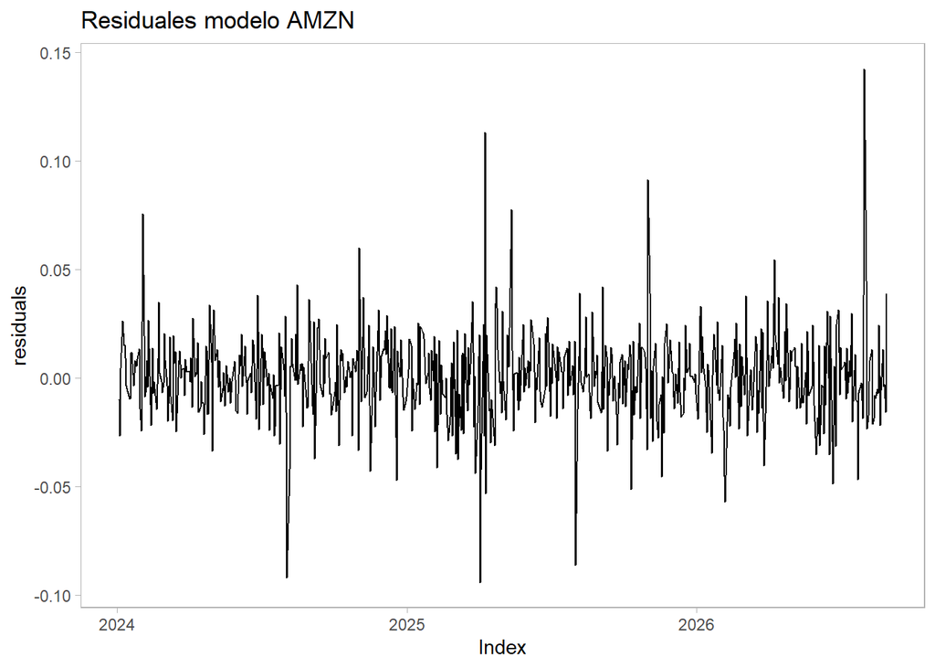

```r
## 3.2. Genreacion de los residuales ----
residuals <- f.arima[["residuals"]] %>%
    xts(order.by = index(retornos$AMZN))

forecast::autoplot(residuals) +
  labs(title = "Residuales modelo AMZN") +
  theme_light() +
  theme(panel.grid = element_blank())
```

**Nota**: como el ARIMA es (0,0,0), los “residuales” del modelo son, matemáticamente, los mismos retornos originales — el modelo no le restó nada a la serie porque no encontró ninguna parte predecible que restar.

## 2.1 Validando el modelo de la media (los 4 supuestos de siempre)

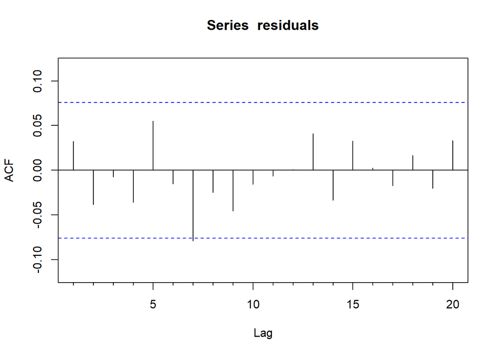

```r
forecast::Acf(residuals, lag.max=20)
```

```r
## 3.3. Prueba de la media ----
t.test(x = coredata(residuals), mu = 0)
```

```
##
##  One Sample t-test
##
## data:  coredata(residuals)
## t = 1.0904, df = 665, p-value = 0.2759
## alternative hypothesis: true mean is not equal to 0
## 95 percent confidence interval:
##  -0.0006912618  0.0024178175
## sample estimates:
##    mean of x
## 0.0008632778
```

```r
## 3.4. Prueba de autocorrelacion ----
tabla.Box.Pierce(residuo = residuals, type = "Ljung-Box")
```

```
##    Rezagos Ljung-Box p-valor
## 1        1     0.699 0.40315
## 2        2     1.687 0.43017
## 3        3     1.725 0.63135
## 4        4     2.584 0.62967
## 5        5     4.632 0.46247
## 6        6     4.784 0.57174
## 7        7     8.974 0.25450
## 8        8     9.393 0.31022
## 9        9    10.784 0.29078
## 10      10    10.947 0.36165
## 11      11    10.975 0.44536
## 12      12    10.976 0.53101
## 13      13    12.125 0.51740
## 14      14    12.894 0.53489
## 15      15    13.628 0.55390
## 16      16    13.633 0.62603
## 17      17    13.833 0.67891
## 18      18    14.023 0.72762
## 19      19    14.306 0.76558
## 20      20    15.062 0.77286
```

```r
## 3.5. Prueba de heterocedasticidad ----
tabla.Box.Pierce(residuo = residuals^2, type = "Ljung-Box")
```

```
##    Rezagos Ljung-Box p-valor
## 1        1    11.708 0.00062
## 2        2    11.763 0.00279
## 3        3    11.821 0.00802
## 4        4    17.620 0.00146
## 5        5    17.622 0.00346
## 6        6    17.709 0.00700
## 7        7    17.720 0.01330
## 8        8    18.499 0.01778
## 9        9    18.628 0.02855
## 10      10    18.828 0.04250
## 11      11    19.172 0.05807
## 12      12    19.525 0.07662
## 13      13    19.528 0.10762
## 14      14    19.584 0.14381
## 15      15    19.590 0.18825
## 16      16    20.368 0.20411
## 17      17    20.631 0.24322
## 18      18    21.300 0.26454
## 19      19    21.451 0.31244
## 20      20    21.572 0.36418
```

```r
tabla.ARCH.LM(residuo = residuals)
```

```
##    Rezagos ARCH LM-EstadÌstico p-valor
## 1        1            11.65286 0.00064
## 2        2            11.70193 0.00288
## 3        3            11.76520 0.00823
## 4        4            17.29595 0.00169
## 5        5            17.73330 0.00330
## 6        6            17.86461 0.00658
## 7        7            17.81106 0.01285
## 8        8            18.20240 0.01976
## 9        9            18.19228 0.03301
## 10      10            18.49623 0.04715
## 11      11            18.63993 0.06787
## 12      12            18.93389 0.09014
## 13      13            18.89610 0.12636
## 14      14            18.85805 0.17044
## 15      15            18.83358 0.22137
## 16      16            19.87483 0.22591
## 17      17            19.86960 0.28095
## 18      18            20.26165 0.31828
## 19      19            20.25612 0.37932
## 20      20            20.58057 0.42218
```

```r
## 3.6. Prueba de normalidad ----
tseries::jarque.bera.test(x = residuals)
```

```
##
##  Jarque Bera Test
##
## data:  residuals
## X-squared = 1256.7, df = 2, p-value < 0.00000000000000022
```

**Interpretación — exactamente el patrón que se esperaba (y buscaba)**:

| Supuesto | Resultado | ¿Se cumple? |
| --- | --- | --- |
| Media = 0 | p=0.28 | Sí |
| No autocorrelación (Ljung-Box) | p entre 0.40 y 0.63 en los primeros 5 rezagos | Sí |
| Varianza constante (Ljung-Box sobre residuales², ARCH-LM) | p entre 0.0006 y 0.008 | **No** |
| Normalidad (Jarque-Bera) | p≈0 | No (la menos crítica) |

El modelo de la media está bien especificado (media cero, sin autocorrelación) — el problema real es exactamente el que motiva esta clase: la varianza **no** es constante. Por la jerarquía de supuestos ya vista (autocorrelación indispensable de corregir, varianza no constante se arregla con un modelo de volatilidad sin tocar el ARIMA), el siguiente paso correcto es ajustar ARCH/GARCH sobre esta misma serie — no replantear el ARIMA, que ya está bien.

## 3. Modelo ARCH(1)

```r
# 4. Modela ARCH para la varianza --------------------------------------------

## 4.1. Estimacion del modelo ARCH(1) en conjunto con un ARIMA(0,0) ----
f.arch <- fGarch::garchFit(formula = AMZN ~ arma(0,0)+garch(1,0),
                           data = retornos,
                           trace = FALSE,
                           include.mean = T)
summary(f.arch)
```

```
##
## Title:
##  GARCH Modelling
##
## Call:
##  fGarch::garchFit(formula = AMZN ~ arma(0, 0) + garch(1, 0), data = retornos,
##     include.mean = T, trace = FALSE)
##
## Mean and Variance Equation:
##  data ~ arma(0, 0) + garch(1, 0)
## <environment: 0x0000019f0fd8a8c8>
##  [data = retornos]
##
## Conditional Distribution:
##  norm
##
## Coefficient(s):
##         mu       omega      alpha1
## 0.00044059  0.00027730  0.42149481
##
## Std. Errors:
##  based on Hessian
##
## Error Analysis:
##          Estimate  Std. Error  t value             Pr(>|t|)
## mu     0.00044059  0.00068608    0.642                0.521
## omega  0.00027730  0.00002296   12.077 < 0.0000000000000002 ***
## alpha1 0.42149481  0.09010766    4.678            0.0000029 ***
## ---
## Signif. codes:  0 '***' 0.001 '**' 0.01 '*' 0.05 '.' 0.1 ' ' 1
##
## Log Likelihood:
##  1672.019    normalized:  2.510539
##
## Description:
##  Mon Oct 12 16:51:01 2026 by user: Andres Londoño P
##
##
##
## Standardised Residuals Tests:
##                                   Statistic              p-Value
##  Jarque-Bera Test   R    Chi^2  324.1718640 0.000000000000000000
##  Shapiro-Wilk Test  R    W        0.9632926 0.000000000007403928
##  Ljung-Box Test     R    Q(10)    9.4121748 0.493483582247389418
##  Ljung-Box Test     R    Q(15)   11.8409667 0.691024614534952120
##  Ljung-Box Test     R    Q(20)   14.2579543 0.817179861005102648
##  Ljung-Box Test     R^2  Q(10)   13.4052904 0.201885787143034068
##  Ljung-Box Test     R^2  Q(15)   15.6273266 0.407242524591037158
##  Ljung-Box Test     R^2  Q(20)   18.1281631 0.578965778442421031
##  LM Arch Test       R    TR^2    13.2063170 0.354224803035747771
##
## Information Criterion Statistics:
##       AIC       BIC       SIC      HQIC
## -5.012069 -4.991793 -5.012109 -5.004213
```

```r
# Eliminemos la constante de la media de la serie

f.arch <- fGarch::garchFit(formula = AMZN ~ arma(0,0)+garch(1,0),
                           data = retornos,
                           trace = FALSE,
                           include.mean = F)
summary(f.arch)
```

```
##
## Title:
##  GARCH Modelling
##
## Call:
##  fGarch::garchFit(formula = AMZN ~ arma(0, 0) + garch(1, 0), data = retornos,
##     include.mean = F, trace = FALSE)
##
## Mean and Variance Equation:
##  data ~ arma(0, 0) + garch(1, 0)
## <environment: 0x0000019f03a77d98>
##  [data = retornos]
##
## Conditional Distribution:
##  norm
##
## Coefficient(s):
##      omega      alpha1
## 0.00027712  0.42290385
##
## Std. Errors:
##  based on Hessian
##
## Error Analysis:
##          Estimate  Std. Error  t value             Pr(>|t|)
## omega  0.00027712  0.00002293    12.09 < 0.0000000000000002 ***
## alpha1 0.42290385  0.08997544     4.70            0.0000026 ***
## ---
## Signif. codes:  0 '***' 0.001 '**' 0.01 '*' 0.05 '.' 0.1 ' ' 1
##
## Log Likelihood:
##  1671.813    normalized:  2.510229
##
## Description:
##  Mon Oct 12 16:51:01 2026 by user: Andres Londoño P
##
##
##
## Standardised Residuals Tests:
##                                   Statistic             p-Value
##  Jarque-Bera Test   R    Chi^2  319.8039549 0.00000000000000000
##  Shapiro-Wilk Test  R    W        0.9636135 0.00000000000857697
##  Ljung-Box Test     R    Q(10)    9.4641363 0.48869289413922989
##  Ljung-Box Test     R    Q(15)   11.9293153 0.68437129678408071
##  Ljung-Box Test     R    Q(20)   14.3311604 0.81331624531660696
##  Ljung-Box Test     R^2  Q(10)   13.2322696 0.21097378020420710
##  Ljung-Box Test     R^2  Q(15)   15.4792928 0.41747510039851332
##  Ljung-Box Test     R^2  Q(20)   18.0253945 0.58573531742063822
##  LM Arch Test       R    TR^2    13.0503623 0.36539079072625280
##
## Information Criterion Statistics:
##       AIC       BIC       SIC      HQIC
## -5.014453 -5.000935 -5.014471 -5.009215
```

**Interpretación**: se corre primero con `include.mean = T` (constante libre) y luego con `include.mean = F` — coherente con haber encontrado un ARIMA(0,0,0) de media cero: no hace falta estimar una media aparte, ya se sabe que es ≈0. El ARCH(1) resultante:

```
omega  = 0.000277  (***, p < 0.001)
alpha1 = 0.4229    (***, p < 0.001)
```

Ambos coeficientes son muy significativos y α₁ es positivo (cumple la restricción de no negatividad de la varianza).

## 3.1 Validando los residuales estandarizados del ARCH(1)

```r
residuales.arch <- fGarch::residuals(object = f.arch, standardize = T)

t.test(residuales.arch)
```

```
##
##  One Sample t-test
##
## data:  residuales.arch
## t = 0.95464, df = 665, p-value = 0.3401
## alternative hypothesis: true mean is not equal to 0
## 95 percent confidence interval:
##  -0.03909641  0.11308479
## sample estimates:
##  mean of x
## 0.03699419
```

```r
tabla.Box.Pierce(residuo = residuales.arch, type = "Ljung-Box")
```

```
##    Rezagos Ljung-Box p-valor
## 1        1     0.004 0.94827
## 2        2     2.337 0.31090
## 3        3     2.414 0.49098
## 4        4     3.459 0.48418
## 5        5     4.528 0.47608
## 6        6     4.546 0.60318
## 7        7     7.486 0.38012
## 8        8     7.590 0.47454
## 9        9     8.933 0.44344
## 10      10     9.464 0.48869
## 11      11     9.542 0.57202
## 12      12     9.623 0.64900
## 13      13    10.868 0.62185
## 14      14    10.937 0.69098
## 15      15    11.929 0.68437
## 16      16    11.954 0.74714
## 17      17    12.874 0.74458
## 18      18    13.946 0.73262
## 19      19    14.253 0.76874
## 20      20    14.331 0.81332
```

```r
tabla.Box.Pierce(residuo = residuales.arch^2, type = "Ljung-Box")
```

```
##    Rezagos Ljung-Box p-valor
## 1        1     0.722 0.39539
## 2        2     0.765 0.68202
## 3        3     0.841 0.83957
## 4        4    10.349 0.03495
## 5        5    10.597 0.05999
## 6        6    10.605 0.10137
## 7        7    10.645 0.15488
## 8        8    12.670 0.12372
## 9        9    12.762 0.17367
## 10      10    13.232 0.21097
## 11      11    13.900 0.23860
## 12      12    14.827 0.25105
## 13      13    14.858 0.31632
## 14      14    14.991 0.37877
## 15      15    15.479 0.41748
## 16      16    17.202 0.37263
## 17      17    17.229 0.43896
## 18      18    17.694 0.47596
## 19      19    17.747 0.53942
## 20      20    18.025 0.58574
```

```r
tabla.ARCH.LM(residuo = residuales.arch)
```

```
##    Rezagos ARCH LM-EstadÌstico p-valor
## 1        1           0.7198585 0.39619
## 2        2           0.7625539 0.68299
## 3        3           0.8331667 0.84152
## 4        4          10.1179112 0.03849
## 5        5          10.1695407 0.07057
## 6        6          10.1861923 0.11703
## 7        7          10.1982099 0.17762
## 8        8          11.3784745 0.18116
## 9        9          11.5721043 0.23852
## 10      10          11.9501115 0.28841
## 11      11          12.6988345 0.31346
## 12      12          13.0503623 0.36539
## 13      13          13.0471124 0.44418
## 14      14          13.0628559 0.52158
## 15      15          13.6955252 0.54874
## 16      16          16.0139593 0.45199
## 17      17          16.0272818 0.52190
## 18      18          16.2950698 0.57196
## 19      19          16.4316378 0.62831
## 20      20          17.0707002 0.64838
```

```r
jarque.bera.test(residuales.arch)
```

```
##
##  Jarque Bera Test
##
## data:  residuales.arch
## X-squared = 319.8, df = 2, p-value < 0.00000000000000022
```

**Interpretación**: aquí es donde se aplica el concepto de **residuo estandarizado** (zₜ = εₜ/σ̂ₜ, dividiendo cada retorno por la volatilidad que el propio ARCH(1) estimó para ese día) — el diagnóstico correcto de un modelo de volatilidad no se hace sobre los residuales crudos, sino sobre estos. Resultado: media (p=0.34) y autocorrelación en la media (rezagos 1 a 5: p = 0.95, 0.31, 0.49, 0.48, 0.48) siguen bien. En la varianza (Ljung-Box y ARCH-LM sobre zₜ²) los primeros 3 rezagos pasan (p>0.39), el **rezago 4 falla puntualmente** (Ljung-Box p=0.035, ARCH-LM p=0.038), el 5 es marginal (p=0.060 y 0.071) y del rezago 6 en adelante vuelve a pasar; los contrastes a rezagos largos del resumen de `fGarch`, Q(10), Q(15) y Q(20) sobre R², también pasan (p entre 0.21 y 0.58). Es decir, el ARCH(1) deja a lo sumo un residuo menor de estructura en el rezago 4 — no una falla generalizada. La limitación teórica de ARCH (una memoria corta, que para capturar más persistencia exigiría más rezagos o pasar a GARCH) se ve aquí de forma leve.

## 3.2 Volatilidad estimada por el ARCH(1)

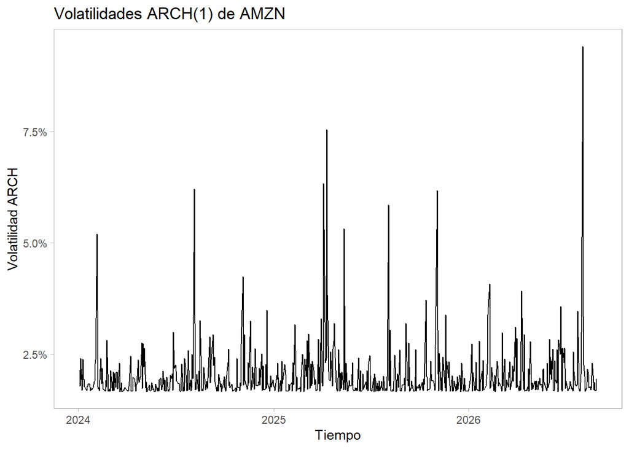

```r
## 4.3. Volatilidad estimada por el modelo ARCH ----
sigma.arch <- xts(f.arch@sigma.t, order.by = index(retornos))

## 4.5. Grafico de la volatilidad ----
p.sigma.arch <- forecast::autoplot(sigma.arch)+
    labs(title = paste("Volatilidades ARCH(1) de AMZN"),
       x = "Tiempo",
       y = "Volatilidad ARCH") +
    scale_y_continuous(labels = label_percent()) +
    theme_light() +
    theme(panel.grid = element_blank())
p.sigma.arch
```

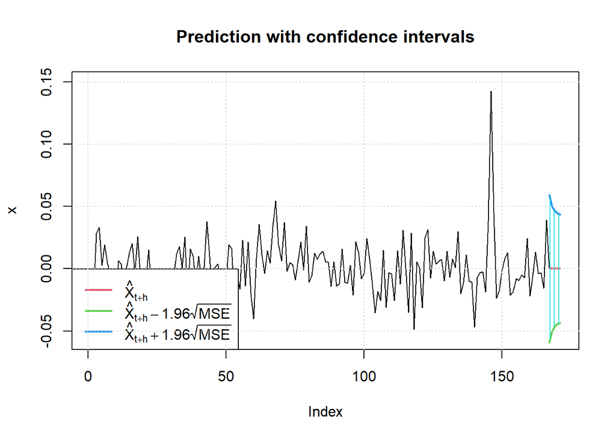

```
##   meanForecast  meanError standardDeviation lowerInterval upperInterval
## 1            0 0.03029337        0.03029337   -0.05937391    0.05937391
## 2            0 0.02579179        0.02579179   -0.05055099    0.05055099
## 3            0 0.02363145        0.02363145   -0.04631680    0.04631680
## 4            0 0.02265594        0.02265594   -0.04440483    0.04440483
## 5            0 0.02223052        0.02223052   -0.04357101    0.04357101
##          VaR         ES
## 1 0.04982815 0.06248651
## 2 0.04242373 0.05320107
## 3 0.03887028 0.04874490
## 4 0.03726571 0.04673270
## 5 0.03656595 0.04585517
```

```r
## 4.6. Prediccion de los retornos y la volatilidad ----
predict(object = f.arch, n.ahead = 5, plot = T, p_loss = 0.05)
```

**Interpretación del pronóstico**: el retorno pronosticado es 0% en los 5 períodos (coherente con el ARIMA(0,0,0) — sin estructura, no hay nada que pronosticar salvo la media cero). Lo que sí cambia es la **volatilidad** pronosticada: empieza en ≈3.03% y decae hacia ≈2.22% en el quinto período — el ARCH(1) converge hacia su volatilidad de largo plazo (≈2.19%, ver √(ω/(1−α))). La velocidad de esa convergencia la fija α₁ (0.42 aquí): el pronóstico a h pasos converge a razón de α₁^h, no depende de “cuántos rezagos” tiene el modelo.

## 4. Volatilidad con modelo GARCH(1,1)

```r
# 5. Volatilidad con modelo GARCH(1,1) ---------------------------------------

garch.arma <- fGarch::garchFit(formula=~arma(0,0)+garch(1,1),
                               data=retornos,
                               trace=FALSE,
                               include.mean = F)
summary(garch.arma)
```

```
##
## Title:
##  GARCH Modelling
##
## Call:
##  fGarch::garchFit(formula = ~arma(0, 0) + garch(1, 1), data = retornos,
##     include.mean = F, trace = FALSE)
##
## Mean and Variance Equation:
##  data ~ arma(0, 0) + garch(1, 1)
## <environment: 0x0000019f0a141000>
##  [data = retornos]
##
## Conditional Distribution:
##  norm
##
## Coefficient(s):
##      omega      alpha1       beta1
## 0.00017751  0.39235382  0.25880966
##
## Std. Errors:
##  based on Hessian
##
## Error Analysis:
##          Estimate  Std. Error  t value  Pr(>|t|)
## omega  0.00017751  0.00004962    3.577  0.000348 ***
## alpha1 0.39235382  0.09099705    4.312 0.0000162 ***
## beta1  0.25880966  0.13791097    1.877  0.060567 .
## ---
## Signif. codes:  0 '***' 0.001 '**' 0.01 '*' 0.05 '.' 0.1 ' ' 1
##
## Log Likelihood:
##  1672.025    normalized:  2.510548
##
## Description:
##  Mon Oct 12 16:51:03 2026 by user: Andres Londoño P
##
##
##
## Standardised Residuals Tests:
##                                   Statistic             p-Value
##  Jarque-Bera Test   R    Chi^2  309.1337415 0.00000000000000000
##  Shapiro-Wilk Test  R    W        0.9645034 0.00000000001295535
##  Ljung-Box Test     R    Q(10)    9.7356034 0.46398797328311137
##  Ljung-Box Test     R    Q(15)   12.3088274 0.65551877337319042
##  Ljung-Box Test     R    Q(20)   14.5080933 0.80382913364358377
##  Ljung-Box Test     R^2  Q(10)   10.9262519 0.36329249017688503
##  Ljung-Box Test     R^2  Q(15)   13.3393659 0.57610334632787119
##  Ljung-Box Test     R^2  Q(20)   16.0069871 0.71619069346220154
##  LM Arch Test       R    TR^2    11.1787760 0.51366293160811549
##
## Information Criterion Statistics:
##       AIC       BIC       SIC      HQIC
## -5.012087 -4.991811 -5.012128 -5.004232
```

**Interpretación**: el GARCH(1,1) resultante:

```
omega  = 0.000178  (***, p < 0.001)
alpha1 = 0.3924    (***, p < 0.001)
beta1  = 0.2588    (·,   p = 0.061 — significativo al 10%)
```

α₁+β₁ ≈ 0.65 — bien por debajo de 1 (modelo estable) y con persistencia moderada. β₁ (el término que le da “memoria de sí mismo” al modelo, ver sección 3 del apunte de EWMA/ARCH-GARCH) es significativo solo al 10% (p=0.061), **no** al 5%, y mucho menos fuerte que α₁.

**Restricciones y varianza de largo plazo**: para que el GARCH(1,1) esté bien definido y sea estacionario se exige ω>0, α≥0, β≥0 y α+β<1; aquí se cumplen todas (ω=0.000178, α=0.392, β=0.259, α+β=0.651). Cuando se cumplen, la varianza incondicional (de largo plazo) es ω/(1−α−β) = 0.00017751/(1−0.65116) ≈ 0.000509, es decir, una volatilidad diaria de largo plazo σ ≈ 2.26%. Para el ARCH(1) la fórmula es √(ω/(1−α)) = √(0.00027712/(1−0.42290)) ≈ 2.19%.

## 4.1 Validando los residuales estandarizados del GARCH(1,1)

```r
residuales.garch <- fGarch::residuals(object = garch.arma, standardize = T)

t.test(residuales.garch)
```

```
##
##  One Sample t-test
##
## data:  residuales.garch
## t = 0.99983, df = 665, p-value = 0.3178
## alternative hypothesis: true mean is not equal to 0
## 95 percent confidence interval:
##  -0.03734026  0.11481939
## sample estimates:
##  mean of x
## 0.03873956
```

```r
tabla.Box.Pierce(residuo = residuales.garch, type = "Ljung-Box")
```

```
##    Rezagos Ljung-Box p-valor
## 1        1     0.003 0.95344
## 2        2     2.148 0.34171
## 3        3     2.329 0.50693
## 4        4     3.113 0.53906
## 5        5     4.062 0.54049
## 6        6     4.159 0.65522
## 7        7     7.309 0.39739
## 8        8     7.505 0.48330
## 9        9     9.196 0.41940
## 10      10     9.736 0.46399
## 11      11     9.810 0.54759
## 12      12     9.834 0.63049
## 13      13    11.350 0.58151
## 14      14    11.428 0.65210
## 15      15    12.309 0.65552
## 16      16    12.313 0.72214
## 17      17    13.143 0.72656
## 18      18    14.130 0.72060
## 19      19    14.481 0.75498
## 20      20    14.508 0.80383
```

```r
tabla.Box.Pierce(residuo = residuales.garch^2, type = "Ljung-Box")
```

```
##    Rezagos Ljung-Box p-valor
## 1        1     0.422 0.51606
## 2        2     0.948 0.62259
## 3        3     1.646 0.64904
## 4        4     8.055 0.08957
## 5        5     8.610 0.12566
## 6        6     8.612 0.19662
## 7        7     8.624 0.28081
## 8        8    10.273 0.24641
## 9        9    10.319 0.32525
## 10      10    10.926 0.36329
## 11      11    11.665 0.38933
## 12      12    12.777 0.38545
## 13      13    12.777 0.46515
## 14      14    12.863 0.53736
## 15      15    13.339 0.57610
## 16      16    14.971 0.52673
## 17      17    15.067 0.59067
## 18      18    15.542 0.62446
## 19      19    15.634 0.68152
## 20      20    16.007 0.71619
```

```r
tabla.ARCH.LM(residuo = residuales.garch)
```

```
##    Rezagos ARCH LM-EstadÌstico p-valor
## 1        1           0.4207162 0.51658
## 2        2           0.9592879 0.61900
## 3        3           1.7116818 0.63434
## 4        4           7.7452130 0.10137
## 5        5           8.1589634 0.14769
## 6        6           8.1863603 0.22477
## 7        7           8.1935673 0.31584
## 8        8           9.2568922 0.32109
## 9        9           9.4019753 0.40103
## 10      10           9.9282907 0.44681
## 11      11          10.5905553 0.47817
## 12      12          11.1787760 0.51366
## 13      13          11.1575461 0.59762
## 14      14          11.1645169 0.67307
## 15      15          11.8037358 0.69382
## 16      16          14.0564388 0.59451
## 17      17          14.1306586 0.65783
## 18      18          14.4809873 0.69724
## 19      19          14.7310186 0.73953
## 20      20          15.3253404 0.75750
```

```r
jarque.bera.test(residuales.garch)
```

```
##
##  Jarque Bera Test
##
## data:  residuales.garch
## X-squared = 309.13, df = 2, p-value < 0.00000000000000022
```

**Interpretación — comparación honesta ARCH(1) vs GARCH(1,1)**: con el GARCH(1,1), el rezago 4 de la varianza (Ljung-Box y ARCH-LM sobre zₜ²) ya no rechaza (p≈0.09-0.10, frente a p≈0.035-0.038 del ARCH(1)), y a rezagos más largos el resumen nativo de `fGarch` muestra Q(10), Q(15), Q(20) sobre R² con p entre 0.36 y 0.72 (ARCH(1): entre 0.21 y 0.58) — en ambos casos sin rechazar. Pero la ventaja es **pequeña**, no decisiva:

- **Ajuste**: log-verosimilitud 1671.81 (ARCH) vs 1672.03 (GARCH), una ganancia de solo 0.21 a cambio de un parámetro más; AIC -5.0145 (ARCH) vs -5.0121 (GARCH) y BIC -5.0009 vs -4.9918: ambos criterios favorecen al ARCH(1).
- **Significancia**: β₁ = 0.259 tiene p=0.061, no significativo al 5%.
- **Residuos del ARCH(1)**: la falla se limita al rezago 4 (Ljung-Box p=0.035, ARCH-LM p=0.038); el rezago 5 es marginal (0.060 y 0.071), del 6 en adelante pasa, y Q(10/15/20) pasan con p entre 0.21 y 0.58.

La ventaja teórica de GARCH(1,1) es que equivale a un ARCH de infinitos rezagos con pesos decrecientes, usando **3 parámetros** (ω, α, β) — en general, 1+p+q — en vez de muchos rezagos; en esta muestra corta (666 observaciones) esa ventaja apenas se materializa. Ninguno de los dos modelos arregla la normalidad (ambos rechazan Jarque-Bera con fuerza) — pero, como ya se vio, ese es el supuesto menos crítico de los cuatro.

## 4.2 Volatilidad estimada por el GARCH(1,1)

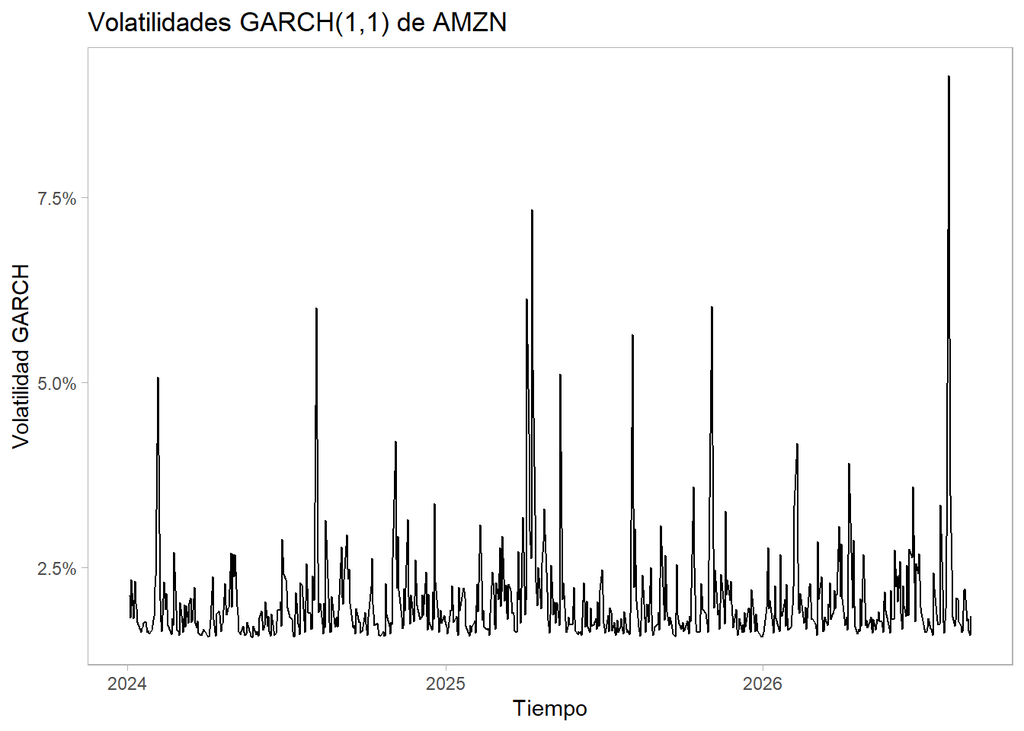

```r
## 5.1. Volatilidad estimada por el modelo ARCH ----
sigma.garch <- xts(x = garch.arma@sigma.t, order.by = index(retornos))

## 5.2. Grafico de la volatilidad ----
p.sigma.garch <- forecast::autoplot(sigma.garch)+
    labs(title = paste("Volatilidades GARCH(1,1) de AMZN"),
       x = "Tiempo",
       y = "Volatilidad GARCH") +
    scale_y_continuous(labels = label_percent()) +
    theme_light() +
    theme(panel.grid = element_blank())
p.sigma.garch
```

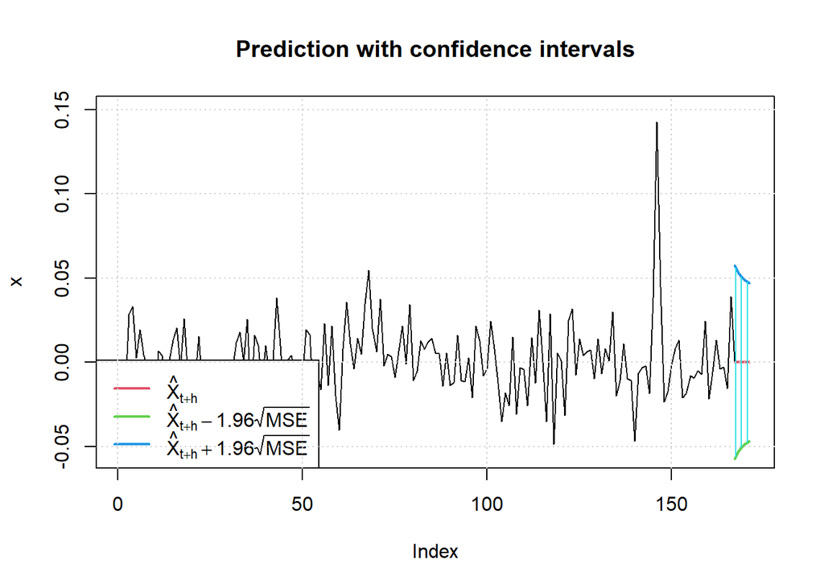

```
##   meanForecast  meanError standardDeviation lowerInterval upperInterval
## 1            0 0.02931066        0.02931066   -0.05744783    0.05744783
## 2            0 0.02714645        0.02714645   -0.05320606    0.05320606
## 3            0 0.02563917        0.02563917   -0.05025185    0.05025185
## 4            0 0.02460811        0.02460811   -0.04823100    0.04823100
## 5            0 0.02391283        0.02391283   -0.04686828    0.04686828
##          VaR         ES
## 1 0.04821174 0.06045946
## 2 0.04465193 0.05599532
## 3 0.04217268 0.05288625
## 4 0.04047673 0.05075946
## 5 0.03933310 0.04932530
```

```r
## 5.3. Prediccion de los retornos y la volatilidad ----
predict(object = garch.arma,
        n.ahead = 5,
        plot = T,
        p_loss = 0.05)
```

**Interpretación**: la volatilidad pronosticada por GARCH(1,1) va de ≈2.93% a ≈2.39% en 5 períodos — decae más **lento** que la del ARCH(1) (3.03%→2.22%). La velocidad a la que el pronóstico converge a la volatilidad de largo plazo la fija la persistencia: α₁ = 0.42 en el ARCH(1) frente a α₁+β₁ = 0.65 en el GARCH(1,1) (el pronóstico a h pasos converge a razón de (α+β)^h), no el número de rezagos. Ambos convergen hacia su propia volatilidad de largo plazo (≈2.19% el ARCH, ≈2.26% el GARCH).

Las tablas `VaR` y `ES` que devuelve `predict(..., p_loss = 0.05)` son el VaR y la pérdida esperada (Expected Shortfall) al 95% de cada horizonte, proporcionales a la desviación estándar pronosticada: por eso también decrecen con el horizonte (en el GARCH, VaR de ≈4.82% a ≈3.93% y ES de ≈6.05% a ≈4.93%).

## 4.3 Comparando el camino completo: in-sample + pronóstico

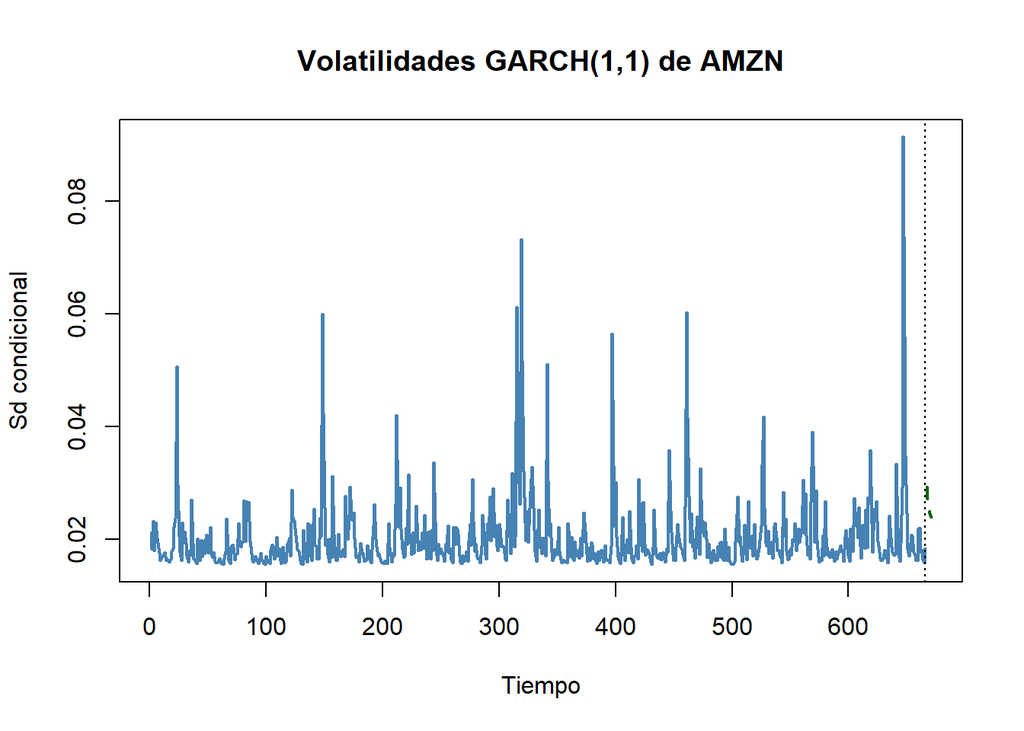

```r
## 5.4. Grafico de prediccion de la volatilidad ----

sigma_in <- volatility(garch.arma, type = "sigma")
sigma_out <- predict(garch.arma, n.ahead = 5, plot = F)[["standardDeviation"]]
sigma_all <- c(sigma_in, sigma_out)
time_all <- 1:(length(sigma_all))

plot(time_all, sigma_all, type = "n",
    xlab = "Tiempo", ylab = "Sd condicional",
    main = "Volatilidades GARCH(1,1) de AMZN")

# in-sample part
lines(1:length(sigma_in), sigma_in, col = "steelblue", lwd = 2)

# forecast part
lines((length(sigma_in) + 1):(length(sigma_in) + 5), sigma_out,
      col = "darkgreen", lwd = 2, lty = 2)

abline(v = length(sigma_in), col = "black", lty = 3)
```

## Conclusión de la clase

|  | ARIMA(0,0,0) | ARCH(1) | GARCH(1,1) |
| --- | --- | --- | --- |
| Qué modela | La media (nada que modelar aquí) | Varianza, 1 rezago de memoria | Varianza, memoria de sí misma + 1 rezago |
| Autocorrelación en la media | Resuelta | — | — |
| Heterocedasticidad (varianza²) | Sin resolver (p<0.01) | Casi resuelta: solo falla puntualmente en el rezago 4 (p≈0.035-0.038), el 5 es marginal (p≈0.06-0.07) y del 6 en adelante pasa; Q(10/15/20) pasan (p entre 0.21 y 0.58) | Resuelta en los rezagos probados (p≥0.09 en el rezago 4; Q(10/15/20) con p entre 0.36 y 0.72) |
| Ajuste (log-verosimilitud / AIC / BIC) | — | 1671.81 / -5.0145 / -5.0009 | 1672.03 / -5.0121 / -4.9918 |
| Parámetros de la varianza | — | 2 (ω, α) | 3 (ω, α, β); β=0.259 con p=0.061 (no significativo al 5%) |
| Normalidad | — | No se cumple | No se cumple |

En estos datos la diferencia entre ARCH(1) y GARCH(1,1) es **pequeña**: el GARCH mejora la log-verosimilitud en apenas 0.21 puntos al costo de un parámetro adicional, y por eso AIC y BIC (que penalizan parámetros) favorecen ligeramente al ARCH(1), el modelo más parsimonioso. El GARCH deja algo menos de estructura residual en el rezago 4, pero el ARCH(1) tampoco queda mal validado: su falla es puntual y los contrastes a rezagos largos pasan. Por tanto, con esta muestra **no hay evidencia sólida de que GARCH(1,1) supere a ARCH(1)**.

El flujo completo de esta clase — eficiencia de mercado (ARIMA vacío) → heterocedasticidad detectada con ARCH-LM → ARCH(1) captura la mayor parte de la dinámica de la varianza → GARCH(1,1) la captura un poco mejor en el rezago 4, sin una mejora decisiva — es el mismo patrón que se vio en teoría. Como regla práctica general, se recomienda empezar por un GARCH(1,1), que rara vez necesita más y suele describir bien la persistencia de la volatilidad en series financieras más largas; aquí, con solo 666 observaciones, la parsimonia del ARCH(1) compite bien.